# SAP PROJEKT - utjecaj glazbe na mentalno zdravlje

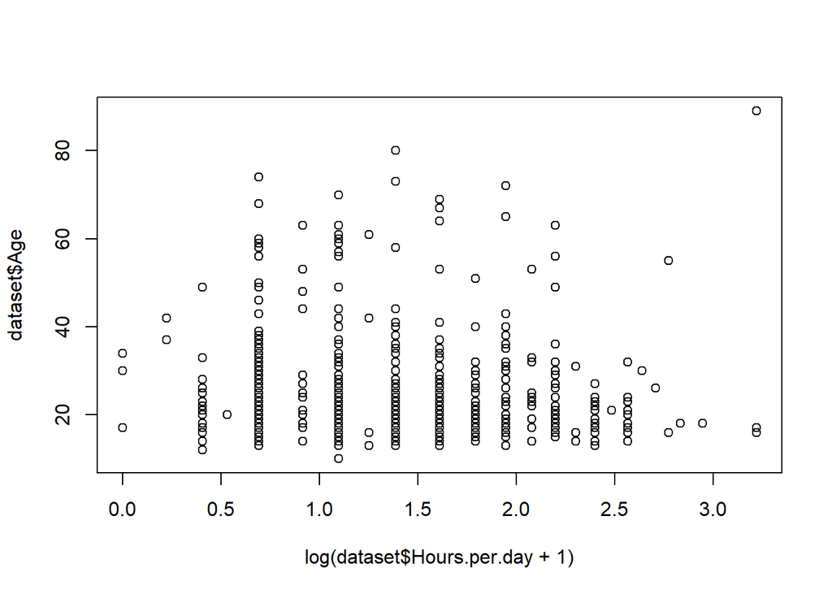

```r
plot(log(dataset$Hours.per.day + 1), dataset$Age)
```

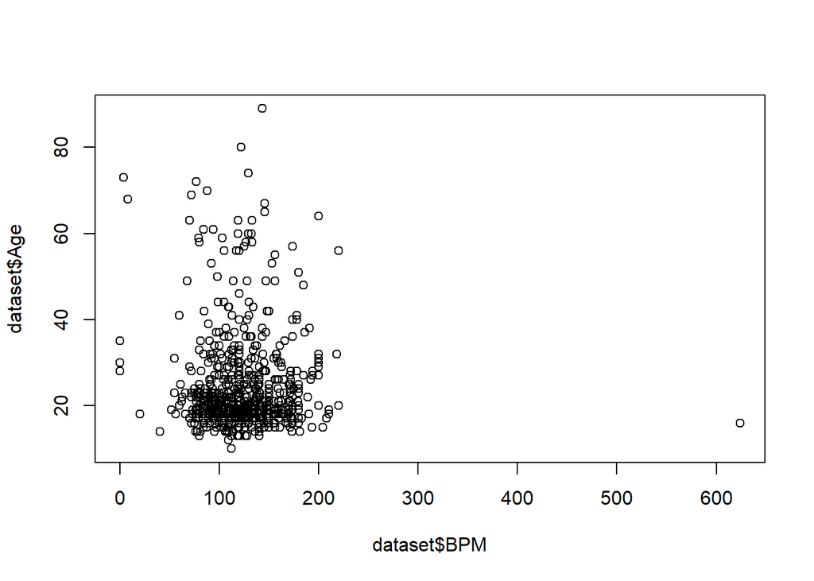

```r
plot(dataset$BPM, dataset$Age)
```

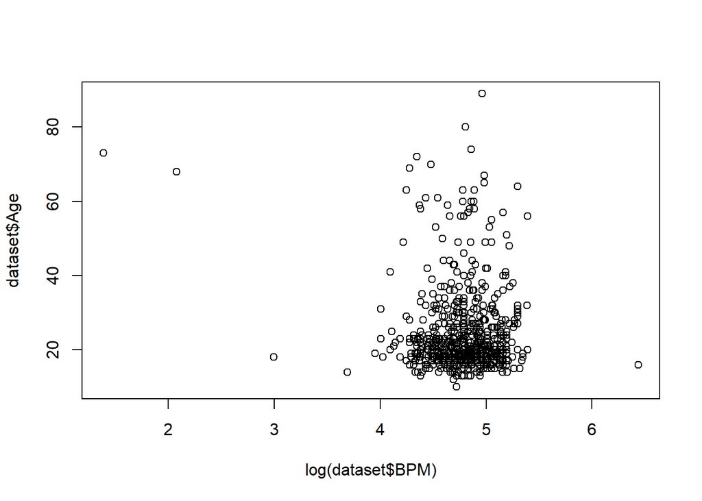

```r
plot(log(dataset$BPM), dataset$Age)
```

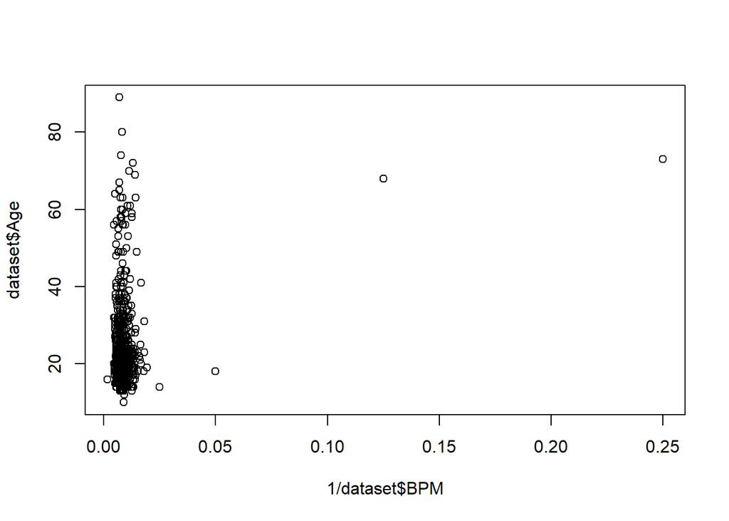

```r
plot(1/dataset$BPM, dataset$Age)
```

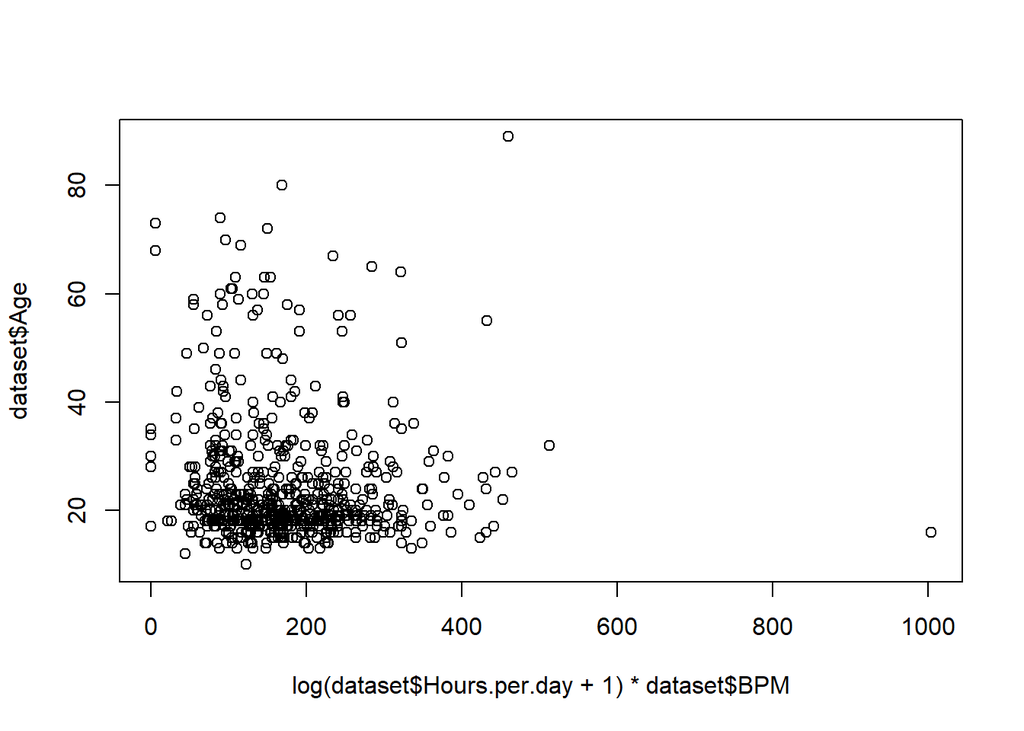

```r
plot(log(dataset$Hours.per.day + 1) * dataset$BPM, dataset$Age)
```

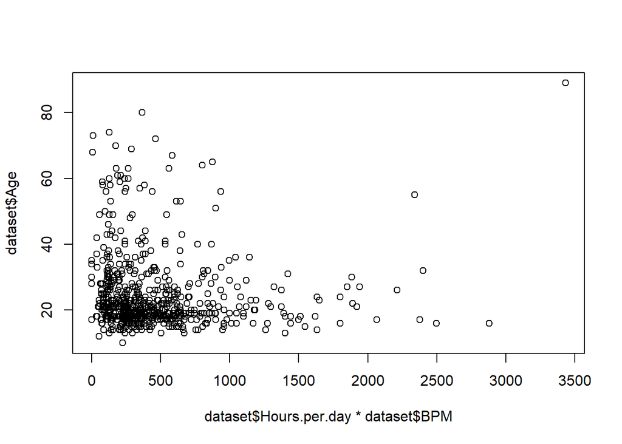

```r
plot(dataset$Hours.per.day * dataset$BPM, dataset$Age)
```

```r
unique(dataset$BPM)
```

```
##   [1] 156 119 132  84 107  86  66  95  94 155  NA 125  88 148 103 120  99 118
##  [19]  79 169 136 101 126 183 142  75  89 140 161  80 130 147  77 115 157  90
##  [37] 128  96  91  55  85 160 108 170 174 127 165 113 167 110 150  93 109 175
##  [55] 162 189 121 200 105 193 149 134 100  98  78 117 122 179 166 144  61 185
##  [73]  92 194  60 190  87 171 114 141 146 164 145 112 111 172 180  76 129  81
##  [91]  52  97 143 158 104 135 220 138 139 178  62  72   0 208  20 124 181 106
## [109] 191  40 173 123   4  73 137 133 102  82 116 131 204 159  70 210   8 153
## [127] 192  56  63  68 624 218 186 163 168
```

Kako bismo utvrdili postoji li potencijalna korist od određenih transformacija, izgradit ćemo linearni model isključivo za njih i analizirati značajnost dobivenog modela.

```r
fit.hours = lm(Age ~ dataset$Hours.per.day, data = dataset)
summary(fit.hours)
```

```
##
## Call:
## lm(formula = Age ~ dataset$Hours.per.day, data = dataset)
##
## Residuals:
##     Min      1Q  Median      3Q     Max
## -15.053  -7.053  -4.053   2.509  67.613
##
## Coefficients:
##                       Estimate Std. Error t value Pr(>|t|)
## (Intercept)            25.3867     0.7289  34.827   <2e-16 ***
## dataset$Hours.per.day  -0.1667     0.1512  -1.102    0.271
## ---
## Signif. codes:  0 '***' 0.001 '**' 0.01 '*' 0.05 '.' 0.1 ' ' 1
##
## Residual standard error: 11.68 on 626 degrees of freedom
##   (107 observations deleted due to missingness)
## Multiple R-squared:  0.001937,   Adjusted R-squared:  0.0003429
## F-statistic: 1.215 on 1 and 626 DF,  p-value: 0.2708
```

```r
fit.bpm = lm(Age ~ dataset$BPM, data = dataset)
summary(fit.bpm)
```

```
##
## Call:
## lm(formula = Age ~ dataset$BPM, data = dataset)
##
## Residuals:
##     Min      1Q  Median      3Q     Max
## -14.910  -7.049  -4.083   2.346  64.473
##
## Coefficients:
##             Estimate Std. Error t value Pr(>|t|)
## (Intercept) 26.29394    1.53647  17.113   <2e-16 ***
## dataset$BPM -0.01235    0.01186  -1.042    0.298
## ---
## Signif. codes:  0 '***' 0.001 '**' 0.01 '*' 0.05 '.' 0.1 ' ' 1
##
## Residual standard error: 11.69 on 626 degrees of freedom
##   (107 observations deleted due to missingness)
## Multiple R-squared:  0.00173,    Adjusted R-squared:  0.0001353
## F-statistic: 1.085 on 1 and 626 DF,  p-value: 0.298
```

```r
fit.hours_tr = lm(Age ~ log(dataset$Hours.per.day + 1), data = dataset)
summary(fit.hours_tr)
```

```
##
## Call:
## lm(formula = Age ~ log(dataset$Hours.per.day + 1), data = dataset)
##
## Residuals:
##     Min      1Q  Median      3Q     Max
## -15.342  -6.959  -4.151   2.261  67.888
##
## Coefficients:
##                                Estimate Std. Error t value Pr(>|t|)
## (Intercept)                     27.5344     1.2529  21.977   <2e-16 ***
## log(dataset$Hours.per.day + 1)  -1.9953     0.8395  -2.377   0.0178 *
## ---
## Signif. codes:  0 '***' 0.001 '**' 0.01 '*' 0.05 '.' 0.1 ' ' 1
##
## Residual standard error: 11.64 on 626 degrees of freedom
##   (107 observations deleted due to missingness)
## Multiple R-squared:  0.008942,   Adjusted R-squared:  0.007359
## F-statistic: 5.648 on 1 and 626 DF,  p-value: 0.01777
```

```r
fit.hours_tr2 = lm(Age ~ dataset$Hours.per.day * dataset$BPM, data = dataset)
summary(fit.hours_tr2)
```

```
##
## Call:
## lm(formula = Age ~ dataset$Hours.per.day * dataset$BPM, data = dataset)
##
## Residuals:
##     Min      1Q  Median      3Q     Max
## -15.393  -6.928  -3.957   2.005  63.179
##
## Coefficients:
##                                    Estimate Std. Error t value Pr(>|t|)
## (Intercept)                       32.313858   2.726575  11.851  < 2e-16 ***
## dataset$Hours.per.day             -1.646041   0.615701  -2.673  0.00770 **
## dataset$BPM                       -0.056333   0.021386  -2.634  0.00865 **
## dataset$Hours.per.day:dataset$BPM  0.011966   0.004817   2.484  0.01324 *
## ---
## Signif. codes:  0 '***' 0.001 '**' 0.01 '*' 0.05 '.' 0.1 ' ' 1
##
## Residual standard error: 11.64 on 624 degrees of freedom
##   (107 observations deleted due to missingness)
## Multiple R-squared:  0.01334,    Adjusted R-squared:  0.008596
## F-statistic: 2.812 on 3 and 624 DF,  p-value: 0.03866
```

Uočavamo da logaritamska transformacija log(dataset$Hours.per.day + 1) ima potencijala za biti uvršena u model (p < 0.05)

```r
print("broj NA vrijednosti u datasetu bez 999999999 vrijednosti za BPM:")
```

```
## [1] "broj NA vrijednosti u datasetu bez 999999999 vrijednosti za BPM:"
```

```r
sum(is.na(dataset))
```

```
## [1] 3531
```

```r
dataset = read.csv("Music and mental health dataset.csv", sep = ",")
print("ukupan broj NA vrijednosti:")
```

```
## [1] "ukupan broj NA vrijednosti:"
```

```r
sum(is.na(dataset))
```

```
## [1] 108
```

```r
dataset <- dataset[, !(names(dataset) %in% c("BPM"))]
print("broj NA vrijednosti nakon micanja stupca BPM")
```

```
## [1] "broj NA vrijednosti nakon micanja stupca BPM"
```

```r
sum(is.na(dataset))
```

```
## [1] 1
```

```r
dataset <- na.omit(dataset)
print("konacni broj NA vrijednosti:")
```

```
## [1] "konacni broj NA vrijednosti:"
```

```r
sum(is.na(dataset))
```

```
## [1] 0
```

Nakon uklonjenog stupca BPM i svih redaka koji sadrže NA, provjeravamo vrijedi li i dalje prijašnji zaključak o logaritamskoj transfromaciji log(dataset$Hours.per.day + 1) te vidimo da je p-vrijednost i dalje manja od 0.05.

```r
fit.hours_tr = lm(Age ~ log(dataset$Hours.per.day + 1), data = dataset)
summary(fit.hours_tr)
```

```
##
## Call:
## lm(formula = Age ~ log(dataset$Hours.per.day + 1), data = dataset)
##
## Residuals:
##     Min      1Q  Median      3Q     Max
## -15.756  -7.256  -4.143   2.380  67.764
##
## Coefficients:
##                                Estimate Std. Error t value Pr(>|t|)
## (Intercept)                     28.0978     1.1695  24.026  < 2e-16 ***
## log(dataset$Hours.per.day + 1)  -2.1316     0.7981  -2.671  0.00773 **
## ---
## Signif. codes:  0 '***' 0.001 '**' 0.01 '*' 0.05 '.' 0.1 ' ' 1
##
## Residual standard error: 12 on 733 degrees of freedom
## Multiple R-squared:  0.009638,   Adjusted R-squared:  0.008287
## F-statistic: 7.134 on 1 and 733 DF,  p-value: 0.007733
```

Kod kategorijskih varijabli, potrebno je koristiti tzv. dummy varijable - svaka kategorija u kategorijskoj varijabli predstavljena je svojom vlastitom indikatorskom varijablom koja poprima vrijednost 1 u slučaju da originalna kategorijska varijabla poprima vrijednost te kategorije, a 0 inače.

Uvijek je potrebno isključiti jednu od dummy varijabli iz modela zbog zavisnosti.

```r
dataset <- dataset[dataset$Primary.streaming.service != "", ]
```

```r
require(fastDummies)
# dodaje dummy stupce u obliku: Primary.streaming.service_Spotify, za svaki servis
dataset_dummy = dummy_cols(dataset,select_columns=c('Primary.streaming.service', "Fav.genre"))

columns_to_remove <- c("Primary.streaming.service", "Timestamp", "Permissions", "Fav.genre")
dataset_dummy <- dataset_dummy[, !(names(dataset_dummy) %in% columns_to_remove)]
```

Izbacivanje po jedne dummy varijable:

```r
require(fastDummies)

columns_to_remove <- c("Primary.streaming.service_I do not use a streaming service.", "Fav.genre_Video game music")
dataset_dummy <- dataset_dummy[, !(names(dataset_dummy) %in% columns_to_remove)]
```

Pretvaranje svih potrebnih vrijednosti u uređajnu skalu:

```r
dataset_dummy$Frequency..Country. <- as.numeric(factor(
  dataset_dummy$Frequency..Country.,
  levels = c("Never", "Rarely", "Sometimes", "frequently", "Very frequently"),
  ordered = TRUE
))

dataset_dummy$Frequency..Folk. <- as.numeric(factor(
  dataset_dummy$Frequency..Folk.,
  levels = c("Never", "Rarely", "Sometimes", "frequently", "Very frequently"),
  ordered = TRUE
))

dataset_dummy$Frequency..Hip.hop. <- as.numeric(factor(
  dataset_dummy$Frequency..Hip.hop.,
  levels = c("Never", "Rarely", "Sometimes", "frequently", "Very frequently"),
  ordered = TRUE
))


dataset_dummy$Frequency..K.pop. <- as.numeric(factor(
  dataset_dummy$Frequency..K.pop.,
  levels = c("Never", "Rarely", "Sometimes", "frequently", "Very frequently"),
  ordered = TRUE
))


dataset_dummy$Frequency..Rock. <- as.numeric(factor(
  dataset_dummy$Frequency..Rock.,
  levels = c("Never", "Rarely", "Sometimes", "frequently", "Very frequently"),
  ordered = TRUE
))


dataset_dummy$Frequency..Lofi. <- as.numeric(factor(
  dataset_dummy$Frequency..Lofi.,
  levels = c("Never", "Rarely", "Sometimes", "frequently", "Very frequently"),
  ordered = TRUE
))


dataset_dummy$Frequency..Pop. <- as.numeric(factor(
  dataset_dummy$Frequency..Pop.,
  levels = c("Never", "Rarely", "Sometimes", "frequently", "Very frequently"),
  ordered = TRUE
))


dataset_dummy$Frequency..Rap. <- as.numeric(factor(
  dataset_dummy$Frequency..Rap.,
  levels = c("Never", "Rarely", "Sometimes", "frequently", "Very frequently"),
  ordered = TRUE
))

dataset_dummy$Frequency..Video.game.music. <- as.numeric(factor(
  dataset_dummy$Frequency..Video.game.music.,
  levels = c("Never", "Rarely", "Sometimes", "frequently", "Very frequently"),
  ordered = TRUE
))


dataset_dummy$Frequency..EDM. <- as.numeric(factor(
  dataset_dummy$Frequency..EDM.,
  levels = c("Never", "Rarely", "Sometimes", "frequently", "Very frequently"),
  ordered = TRUE
))

dataset_dummy$Frequency..Gospel. <- as.numeric(factor(
  dataset_dummy$Frequency..Gospel.,
  levels = c("Never", "Rarely", "Sometimes", "frequently", "Very frequently"),
  ordered = TRUE
))

dataset_dummy$Frequency..Metal. <- as.numeric(factor(
  dataset_dummy$Frequency..Metal.,
  levels = c("Never", "Rarely", "Sometimes", "frequently", "Very frequently"),
  ordered = TRUE
))

dataset_dummy$Frequency..Latin. <- as.numeric(factor(
  dataset_dummy$Frequency..Latin.,
  levels = c("Never", "Rarely", "Sometimes", "frequently", "Very frequently"),
  ordered = TRUE
))

dataset_dummy$Frequency..R.B. <- as.numeric(factor(
  dataset_dummy$Frequency..R.B.,
  levels = c("Never", "Rarely", "Sometimes", "frequently", "Very frequently"),
  ordered = TRUE
))

dataset_dummy$Frequency..Jazz. <- as.numeric(factor(
  dataset_dummy$Frequency..Jazz.,
  levels = c("Never", "Rarely", "Sometimes", "frequently", "Very frequently"),
  ordered = TRUE
))

dataset_dummy$Frequency..Classical. <- as.numeric(factor(
  dataset_dummy$Frequency..Classical.,
  levels = c("Never", "Rarely", "Sometimes", "frequently", "Very frequently"),
  ordered = TRUE
))


dataset_dummy$While.working <- ifelse(dataset_dummy$While.working == "Yes", 1, 0)

dataset_dummy$Instrumentalist <- ifelse(dataset_dummy$Instrumentalist == "Yes", 1, 0)

dataset_dummy$Composer <- ifelse(dataset_dummy$Composer == "Yes", 1, 0)

dataset_dummy$Exploratory <- ifelse(dataset_dummy$Exploratory == "Yes", 1, 0)

dataset_dummy$Foreign.languages <- ifelse(dataset_dummy$Foreign.languages == "Yes", 1, 0)

dataset_dummy <- dataset_dummy[dataset_dummy$Music.effects != "", ]
unique(dataset_dummy$Music.effects)
```

```
## [1] "No effect" "Improve"   "Worsen"
```

```r
dataset_dummy$Music.effects <- as.numeric(factor(
  dataset_dummy$Music.effects,
  levels = c("No effect", "Improve",  "Worsen"),
  ordered = TRUE
))

#mozemo vidjeti kakve nam sada vrijednosti poprimaju za sve dodane dummy varijable i varijable prebačene u uređajnu skalu
head(dataset_dummy)
```

|  | Age | Hours.per.day | While.working | Instrumentalist | Composer | Exploratory | Foreign.languages | Frequency..Classical. | Frequency..Country. | Frequency..EDM. | Frequency..Folk. | Frequency..Gospel. | Frequency..Hip.hop. | Frequency..Jazz. | Frequency..K.pop. | Frequency..Latin. | Frequency..Lofi. | Frequency..Metal. | Frequency..Pop. | Frequency..R.B. | Frequency..Rap. | Frequency..Rock. | Frequency..Video.game.music. | Anxiety | Depression | Insomnia | OCD | Music.effects | Primary.streaming.service_Apple Music | … |
| --- | --- | --- | --- | --- | --- | --- | --- | --- | --- | --- | --- | --- | --- | --- | --- | --- | --- | --- | --- | --- | --- | --- | --- | --- | --- | --- | --- | --- | --- | --- |
| 3 | 18 | 4.0 | 0 | 0 | 0 | 0 | 1 | 1 | 1 | 5 | 1 | 1 | 2 | 2 | 5 | 1 | 3 | 3 | 2 | 1 | 2 | 2 | 5 | 7 | 7 | 10 | 2 | 1 | 0 | … |
| 4 | 61 | 2.5 | 1 | 0 | 1 | 1 | 1 | 3 | 1 | 1 | 2 | 3 | 1 | 5 | 3 | 5 | 3 | 1 | 3 | 3 | 1 | 1 | 1 | 9 | 7 | 3 | 3 | 2 | 0 | … |
| 5 | 18 | 4.0 | 1 | 0 | 0 | 1 | 0 | 1 | 1 | 2 | 1 | 2 | 5 | 1 | 5 | 3 | 3 | 1 | 3 | 5 | 5 | 1 | 2 | 7 | 2 | 5 | 9 | 2 | 0 | … |
| 6 | 18 | 5.0 | 1 | 1 | 1 | 1 | 1 | 2 | 3 | 1 | 1 | 1 | 3 | 5 | 5 | 2 | 5 | 2 | 5 | 5 | 5 | 5 | 1 | 8 | 8 | 7 | 7 | 2 | 0 | … |
| 7 | 18 | 3.0 | 1 | 1 | 0 | 1 | 1 | 3 | 1 | 2 | 3 | 2 | 2 | 3 | 1 | 2 | 2 | 2 | 2 | 2 | 1 | 1 | 3 | 4 | 8 | 6 | 0 | 2 | 0 | … |
| 8 | 21 | 1.0 | 1 | 0 | 0 | 1 | 1 | 1 | 1 | 2 | 1 | 1 | 5 | 2 | 5 | 1 | 3 | 1 | 3 | 3 | 2 | 1 | 2 | 5 | 3 | 5 | 3 | 2 | 0 | … |

Kako bi ispravno usporedili modele, potrebno je provjeriti da pretpostavke modela nisu (jako) narušene.

Prepostavke:

- regresori (multivarijatna regresija - regresori ne smiju biti međusobno jako korelirani)
- reziduali (normalnost reziduala, homogenost varijance)

```r
# provjeriti nezavisnost regresora ( + ostatak na kraju nakon definicije modela)
# Korelacija između regresora

# Korelacije između svih regresora
cor_matrix <- cor(dataset_dummy)
#print(cor_matrix)
```

Za bolju preglednost iz matrice korelacija ispisujemo 30 najvećih korelacija te varijable na koje se te vrijednosti odnose.

```r
diag(cor_matrix) <- NA
library(reshape2)
cor_df <- melt(cor_matrix, na.rm = TRUE)
cor_df <- cor_df[cor_df$value < 1, ]
top_correlations <- cor_df[order(-cor_df$value), ][1:30, ]
print(top_correlations)
```

```
##                       Var1                  Var2     value
## 597        Frequency..Rap.   Frequency..Hip.hop. 0.7784106
## 973    Frequency..Hip.hop.       Frequency..Rap. 0.7784106
## 860        Fav.genre_Metal     Frequency..Metal. 0.6150723
## 2082     Frequency..Metal.       Fav.genre_Metal 0.6150723
## 370    Fav.genre_Classical Frequency..Classical. 0.5402298
## 1592 Frequency..Classical.   Fav.genre_Classical 0.5402298
## 596        Frequency..R.B.   Frequency..Hip.hop. 0.5273159
## 925    Frequency..Hip.hop.       Frequency..R.B. 0.5273159
## 419      Fav.genre_Country   Frequency..Country. 0.5267825
## 1641   Frequency..Country.     Fav.genre_Country 0.5267825
## 1129            Depression               Anxiety 0.5168496
## 1176               Anxiety            Depression 0.5168496
## 468          Fav.genre_EDM       Frequency..EDM. 0.5019777
## 1690       Frequency..EDM.         Fav.genre_EDM 0.5019777
```

[output cut: 16 more lines]

Uočena je visoka korelacija između sljedećih parova varijabli: Frequency..Rap. i Frequency..Hip.hop. (77.84%), Fav.genre_Metal i Frequency..Metal. (61.51%), …

To treba uzeti u obzir pri izradi modela, jer visoka korelacija između varijabli može dovesti do višestruke kolinearnosti. Ako se odlučimo uključiti jednu varijablu iz takvih parova u konačni model, potrebno je ukloniti onu varijablu koja je visoko korelirana s njom kako bi se izbjegli problemi u procjeni koeficijenata i osigurala interpretabilnost modela.

Model sa svim stupcima:

```r
# Višestruka linearna regresija
fit.multi = lm(Age ~ ., data = dataset_dummy)

# Sažetak modela
summary(fit.multi)
```

```
##
## Call:
## lm(formula = Age ~ ., data = dataset_dummy)
##
## Residuals:
##     Min      1Q  Median      3Q     Max
## -24.311  -5.782  -1.648   4.160  61.889
##
## Coefficients:
##                                                      Estimate Std. Error
## (Intercept)                                         35.388622   3.068745
## Hours.per.day                                        0.019817   0.136484
## While.working                                        0.025669   0.989821
## Instrumentalist                                     -3.626124   0.956125
## Composer                                            -0.574793   1.115380
## Exploratory                                         -2.524491   0.936787
## Foreign.languages                                   -0.741657   0.858677
## Frequency..Classical.                                0.990696   0.390262
## Frequency..Country.                                  0.850819   0.457912
## Frequency..EDM.                                      0.502436   0.368040
## Frequency..Folk.                                     0.666501   0.389090
## Frequency..Gospel.                                   0.018246   0.579100
## Frequency..Hip.hop.                                 -0.176305   0.504148
## Frequency..Jazz.                                     1.054431   0.435777
## Frequency..K.pop.                                   -0.346565   0.408725
## Frequency..Latin.                                    0.592465   0.432912
## Frequency..Lofi.                                    -0.822796   0.359983
## Frequency..Metal.                                   -0.154873   0.396348
## Frequency..Pop.                                     -1.241664   0.355778
## Frequency..R.B.                                      1.391404   0.402164
## Frequency..Rap.                                     -1.156706   0.493239
## Frequency..Rock.                                    -0.032441   0.364806
## Frequency..Video.game.music.                        -1.517552   0.352222
## Anxiety                                             -0.436997   0.168763
## Depression                                          -0.099470   0.155579
## Insomnia                                             0.267783   0.136934
## OCD                                                 -0.285568   0.143727
## Music.effects                                       -0.537178   0.842700
## `Primary.streaming.service_Apple Music`             -3.800104   1.961212
## `Primary.streaming.service_Other streaming service`  0.001553   1.927789
```

[output cut: 58 more lines]

```
## Fav.genre_Jazz                                        0.138 0.890480
## `Fav.genre_K pop`                                    -0.624 0.532662
## Fav.genre_Latin                                      -0.612 0.540715
## Fav.genre_Lofi                                        0.450 0.652918
## Fav.genre_Metal                                       1.325 0.185535
## Fav.genre_Pop                                         0.614 0.539700
## `Fav.genre_R&B`                                      -0.464 0.642848
## Fav.genre_Rap                                         0.667 0.505289
## Fav.genre_Rock                                        1.946 0.052126 .
## ---
## Signif. codes:  0 '***' 0.001 '**' 0.01 '*' 0.05 '.' 0.1 ' ' 1
##
## Residual standard error: 9.919 on 678 degrees of freedom
## Multiple R-squared:  0.3541, Adjusted R-squared:  0.3093
## F-statistic: 7.907 on 47 and 678 DF,  p-value: < 2.2e-16
```

Značajne varijable (p < 0.05): Instrumentalist, Exploratory, Frequency..Classical., Frequency..Jazz., Frequency..Lofi., Frequency..Pop., Frequency..R.B., Frequency..Rap., Anxiety, OCD, Frequency..Video.game.music., Primary.streaming.service_Pandora, Primary.streaming.service_Spotify, Fav.genre_Gospel

Model sa značajnim stupcima:

```r
# Višestruka linearna regresija (varijable p < 0.05)
fit.multi2 = lm(Age ~ Instrumentalist + Exploratory + Frequency..Classical. + Frequency..Jazz. + Frequency..Lofi. + Frequency..Pop. + Frequency..R.B. + Frequency..Rap.+ Anxiety + OCD + Frequency..Video.game.music. + Primary.streaming.service_Pandora + Primary.streaming.service_Spotify + Fav.genre_Gospel, data = dataset_dummy)

# Sažetak modela
summary(fit.multi2)
```

```
##
## Call:
## lm(formula = Age ~ Instrumentalist + Exploratory + Frequency..Classical. +
##     Frequency..Jazz. + Frequency..Lofi. + Frequency..Pop. + Frequency..R.B. +
##     Frequency..Rap. + Anxiety + OCD + Frequency..Video.game.music. +
##     Primary.streaming.service_Pandora + Primary.streaming.service_Spotify +
##     Fav.genre_Gospel, data = dataset_dummy)
##
## Residuals:
##     Min      1Q  Median      3Q     Max
## -23.094  -6.622  -2.177   4.397  62.308
##
## Coefficients:
##                                   Estimate Std. Error t value Pr(>|t|)
## (Intercept)                        38.8805     1.7397  22.349  < 2e-16 ***
## Instrumentalist                    -4.2519     0.8643  -4.920 1.08e-06 ***
## Exploratory                        -2.4470     0.8901  -2.749 0.006127 **
## Frequency..Classical.               0.5900     0.3219   1.833 0.067249 .
## Frequency..Jazz.                    1.3340     0.3861   3.455 0.000583 ***
## Frequency..Lofi.                   -0.8050     0.3417  -2.356 0.018743 *
## Frequency..Pop.                    -1.2896     0.3067  -4.205 2.95e-05 ***
## Frequency..R.B.                     1.1991     0.3592   3.338 0.000888 ***
## Frequency..Rap.                    -1.4182     0.3350  -4.233 2.61e-05 ***
## Anxiety                            -0.4053     0.1455  -2.786 0.005473 **
## OCD                                -0.2023     0.1420  -1.425 0.154608
## Frequency..Video.game.music.       -1.3996     0.3020  -4.635 4.24e-06 ***
## Primary.streaming.service_Pandora  14.0535     3.3897   4.146 3.79e-05 ***
## Primary.streaming.service_Spotify  -3.4469     0.8146  -4.231 2.63e-05 ***
## Fav.genre_Gospel                   19.1486     4.3532   4.399 1.26e-05 ***
## ---
## Signif. codes:  0 '***' 0.001 '**' 0.01 '*' 0.05 '.' 0.1 ' ' 1
##
## Residual standard error: 10.12 on 711 degrees of freedom
## Multiple R-squared:  0.2951, Adjusted R-squared:  0.2813
## F-statistic: 21.27 on 14 and 711 DF,  p-value: < 2.2e-16
```

Uočavamo da je novi Adjusted R-squared = 0.2813 manji od početnog za fit.multi od 0.3093, ali ima manje varijabli.

Probat ćemo proširiti kriterij značajnosti u odnosu na prethodni model, tako da kao značajne uvrstimo i varijable za koje vrijedi p < 0.1, umjesto samo onih s p < 0.05. Na taj način, ukoliko primijetimo povećanje prilagođenog R² (Adjusted R-squared), razmotrit ćemo uključivanje tih varijabli u konačni model.

Nove značajne varijable (p < 0.1): Instrumentalist, Exploratory, Frequency..Classical., Frequency..Jazz., Frequency..Lofi., Frequency..Pop., Frequency..R.B., Frequency..Rap., Anxiety, OCD, Frequency..Video.game.music., Primary.streaming.service_Pandora, Primary.streaming.service_Spotify, Fav.genre_Gospel, Frequency..Country., Frequency..Folk., Insomnia, `Primary.streaming.service_Apple Music`, `Primary.streaming.service_YouTube Music`, Fav.genre_Rock

```r
# Višestruka linearna regresija (varijable p < 0.1)
fit.multi22 = lm(Age ~ Instrumentalist + Exploratory + Frequency..Classical. + Frequency..Jazz. + Frequency..Lofi. + Frequency..Pop. + Frequency..R.B. + Frequency..Rap.+ Anxiety + OCD + Frequency..Video.game.music. + Primary.streaming.service_Pandora + Primary.streaming.service_Spotify + Fav.genre_Gospel + Frequency..Country. + Frequency..Folk. + Insomnia + `Primary.streaming.service_Apple Music` + `Primary.streaming.service_YouTube Music` + Fav.genre_Rock, data = dataset_dummy)

# Sažetak modela
summary(fit.multi22)
```

```
##
## Call:
## lm(formula = Age ~ Instrumentalist + Exploratory + Frequency..Classical. +
##     Frequency..Jazz. + Frequency..Lofi. + Frequency..Pop. + Frequency..R.B. +
##     Frequency..Rap. + Anxiety + OCD + Frequency..Video.game.music. +
##     Primary.streaming.service_Pandora + Primary.streaming.service_Spotify +
##     Fav.genre_Gospel + Frequency..Country. + Frequency..Folk. +
##     Insomnia + `Primary.streaming.service_Apple Music` + `Primary.streaming.service_YouTube Music` +
##     Fav.genre_Rock, data = dataset_dummy)
##
## Residuals:
##     Min      1Q  Median      3Q     Max
## -21.632  -6.286  -1.680   4.193  63.480
##
## Coefficients:
##                                           Estimate Std. Error t value Pr(>|t|)
## (Intercept)                                35.9697     1.9390  18.551  < 2e-16
## Instrumentalist                            -3.8529     0.8452  -4.559 6.07e-06
## Exploratory                                -2.5284     0.8859  -2.854 0.004442
## Frequency..Classical.                       0.6502     0.3178   2.046 0.041128
## Frequency..Jazz.                            1.1103     0.3791   2.928 0.003516
## Frequency..Lofi.                           -0.8233     0.3342  -2.463 0.014010
## Frequency..Pop.                            -1.2199     0.2999  -4.068 5.29e-05
## Frequency..R.B.                             1.2546     0.3501   3.583 0.000363
## Frequency..Rap.                            -1.1556     0.3311  -3.490 0.000513
## Anxiety                                    -0.5128     0.1475  -3.476 0.000539
## OCD                                        -0.2617     0.1399  -1.871 0.061826
## Frequency..Video.game.music.               -1.4320     0.2971  -4.819 1.77e-06
## Primary.streaming.service_Pandora          12.0650     3.3931   3.556 0.000402
## Primary.streaming.service_Spotify          -5.3738     1.0733  -5.007 6.99e-07
## Fav.genre_Gospel                           19.6180     4.2641   4.601 4.99e-06
## Frequency..Country.                         0.6568     0.3576   1.837 0.066638
## Frequency..Folk.                            0.8360     0.3301   2.532 0.011553
## Insomnia                                    0.2823     0.1273   2.217 0.026936
## `Primary.streaming.service_Apple Music`    -4.0033     1.7145  -2.335 0.019825
## `Primary.streaming.service_YouTube Music`  -2.6477     1.3924  -1.902 0.057639
## Fav.genre_Rock                              3.1861     0.8809   3.617 0.000320
##
## (Intercept)                               ***
## Instrumentalist                           ***
```

[output cut: 10 more lines]

```
## Primary.streaming.service_Pandora         ***
## Primary.streaming.service_Spotify         ***
## Fav.genre_Gospel                          ***
## Frequency..Country.                       .
## Frequency..Folk.                          *
## Insomnia                                  *
## `Primary.streaming.service_Apple Music`   *
## `Primary.streaming.service_YouTube Music` .
## Fav.genre_Rock                            ***
## ---
## Signif. codes:  0 '***' 0.001 '**' 0.01 '*' 0.05 '.' 0.1 ' ' 1
##
## Residual standard error: 9.851 on 705 degrees of freedom
## Multiple R-squared:  0.3375, Adjusted R-squared:  0.3187
## F-statistic: 17.96 on 20 and 705 DF,  p-value: < 2.2e-16
```

Uočavamo da smo dodavanjem varijabli s p < 0.1 uspjeli povećati Adjusted R-squared s 0.2813 na 0.3187, što predstavlja najbolji rezultat do sada.

Uočavamo da su u novom modelu sve varijable značajne na razini 0.05, osim OCD, Frequency..Country. i `Primary.streaming.service_YouTube Music` Pokušajmo ih izbaciti iz modela u nadi da ćemo time možda povećati Adjusted R-squared:

```r
# Višestruka linearna regresija
fit.multi3 = lm(Age ~ Instrumentalist + Exploratory + Frequency..Classical. + Frequency..Jazz. + Frequency..Lofi. + Frequency..Pop. + Frequency..R.B. + Frequency..Rap.+ Anxiety + Frequency..Video.game.music. + Primary.streaming.service_Pandora + Primary.streaming.service_Spotify + Fav.genre_Gospel + Frequency..Folk. + Insomnia + `Primary.streaming.service_Apple Music` + Fav.genre_Rock, data = dataset_dummy)

# Sažetak modela
summary(fit.multi3)
```

```
##
## Call:
## lm(formula = Age ~ Instrumentalist + Exploratory + Frequency..Classical. +
##     Frequency..Jazz. + Frequency..Lofi. + Frequency..Pop. + Frequency..R.B. +
##     Frequency..Rap. + Anxiety + Frequency..Video.game.music. +
##     Primary.streaming.service_Pandora + Primary.streaming.service_Spotify +
##     Fav.genre_Gospel + Frequency..Folk. + Insomnia + `Primary.streaming.service_Apple Music` +
##     Fav.genre_Rock, data = dataset_dummy)
##
## Residuals:
##     Min      1Q  Median      3Q     Max
## -22.292  -6.300  -1.701   4.305  62.680
##
## Coefficients:
##                                         Estimate Std. Error t value Pr(>|t|)
## (Intercept)                              36.1326     1.7962  20.116  < 2e-16
## Instrumentalist                          -3.8936     0.8486  -4.588 5.28e-06
## Exploratory                              -2.7626     0.8814  -3.134 0.001794
## Frequency..Classical.                     0.5993     0.3189   1.879 0.060625
## Frequency..Jazz.                          1.1569     0.3806   3.040 0.002455
## Frequency..Lofi.                         -0.8674     0.3352  -2.587 0.009872
## Frequency..Pop.                          -1.2132     0.3009  -4.032 6.14e-05
## Frequency..R.B.                           1.2065     0.3512   3.435 0.000626
## Frequency..Rap.                          -1.1403     0.3328  -3.427 0.000646
## Anxiety                                  -0.5949     0.1418  -4.194 3.09e-05
## Frequency..Video.game.music.             -1.4671     0.2978  -4.927 1.04e-06
## Primary.streaming.service_Pandora        13.6274     3.3412   4.079 5.05e-05
## Primary.streaming.service_Spotify        -4.2411     0.8656  -4.900 1.19e-06
## Fav.genre_Gospel                         19.7883     4.2715   4.633 4.30e-06
## Frequency..Folk.                          0.9813     0.3133   3.132 0.001809
## Insomnia                                  0.2438     0.1264   1.929 0.054102
## `Primary.streaming.service_Apple Music`  -2.8347     1.6008  -1.771 0.077026
## Fav.genre_Rock                            3.1704     0.8838   3.587 0.000357
##
## (Intercept)                             ***
## Instrumentalist                         ***
## Exploratory                             **
## Frequency..Classical.                   .
## Frequency..Jazz.                        **
## Frequency..Lofi.                        **
## Frequency..Pop.                         ***
## Frequency..R.B.                         ***
## Frequency..Rap.                         ***
## Anxiety                                 ***
## Frequency..Video.game.music.            ***
## Primary.streaming.service_Pandora       ***
## Primary.streaming.service_Spotify       ***
## Fav.genre_Gospel                        ***
## Frequency..Folk.                        **
## Insomnia                                .
## `Primary.streaming.service_Apple Music` .
## Fav.genre_Rock                          ***
## ---
## Signif. codes:  0 '***' 0.001 '**' 0.01 '*' 0.05 '.' 0.1 ' ' 1
##
## Residual standard error: 9.902 on 708 degrees of freedom
## Multiple R-squared:  0.3278, Adjusted R-squared:  0.3117
## F-statistic: 20.31 on 17 and 708 DF,  p-value: < 2.2e-16
```

Nažalost, Adjusted R-squared se smanjio, stoga ostajemo pri modelu fit.multi22, koji uključuje varijable s p-vrijednostima malo iznad 0.05, ali koje i dalje pružaju određeni doprinos ukupnoj vrijednosti Adjusted R-squared.

Model s višim Adjusted R-squared i više varijabli može biti bolji jer objašnjava veću količinu varijabilnosti u podacima, može donijeti preciznija predviđanja i obuhvatiti dublje odnose među varijablama. Ipak, važno je paziti na prekomjerno prilagođavanje (overfitting) modela.

Pokušajmo u model uvrstiti i kontinuiranu varijablu Hours.per.day s transformacijom log(dataset$Hours.per.day + 1)

```r
dataset_dummy2 <- dataset_dummy
dataset_dummy2$log_Hours_per_day <- log(dataset_dummy2$Hours.per.day + 1)
```

```r
# Višestruka linearna regresija s transformiranom varijablom
fit.multi33 <- lm(Age ~ Instrumentalist + Exploratory + Frequency..Classical. + Frequency..Jazz. + Frequency..Lofi. + Frequency..Pop. + Frequency..R.B. + Frequency..Rap. + Anxiety + OCD + Frequency..Video.game.music. + Primary.streaming.service_Pandora + Primary.streaming.service_Spotify + Fav.genre_Gospel + Frequency..Country. + Frequency..Folk. + Insomnia + `Primary.streaming.service_Apple Music` + `Primary.streaming.service_YouTube Music` + Fav.genre_Rock + log_Hours_per_day,
                  data = dataset_dummy2)

# Sažetak modela
summary(fit.multi33)
```

```
##
## Call:
## lm(formula = Age ~ Instrumentalist + Exploratory + Frequency..Classical. +
##     Frequency..Jazz. + Frequency..Lofi. + Frequency..Pop. + Frequency..R.B. +
##     Frequency..Rap. + Anxiety + OCD + Frequency..Video.game.music. +
##     Primary.streaming.service_Pandora + Primary.streaming.service_Spotify +
##     Fav.genre_Gospel + Frequency..Country. + Frequency..Folk. +
##     Insomnia + `Primary.streaming.service_Apple Music` + `Primary.streaming.service_YouTube Music` +
##     Fav.genre_Rock + log_Hours_per_day, data = dataset_dummy2)
##
## Residuals:
##     Min      1Q  Median      3Q     Max
## -21.077  -6.278  -1.747   4.171  64.586
##
## Coefficients:
##                                           Estimate Std. Error t value Pr(>|t|)
## (Intercept)                                36.4675     2.0223  18.032  < 2e-16
## Instrumentalist                            -3.8656     0.8455  -4.572 5.70e-06
## Exploratory                                -2.4519     0.8904  -2.754 0.006044
## Frequency..Classical.                       0.6429     0.3180   2.022 0.043548
## Frequency..Jazz.                            1.1341     0.3802   2.983 0.002953
## Frequency..Lofi.                           -0.8131     0.3345  -2.431 0.015311
## Frequency..Pop.                            -1.2422     0.3011  -4.126 4.13e-05
## Frequency..R.B.                             1.2672     0.3505   3.615 0.000321
## Frequency..Rap.                            -1.1240     0.3332  -3.374 0.000782
## Anxiety                                    -0.5142     0.1475  -3.485 0.000522
## OCD                                        -0.2507     0.1405  -1.784 0.074854
## Frequency..Video.game.music.               -1.4297     0.2972  -4.811 1.84e-06
## Primary.streaming.service_Pandora          12.0379     3.3938   3.547 0.000415
## Primary.streaming.service_Spotify          -5.2822     1.0786  -4.897 1.21e-06
## Fav.genre_Gospel                           19.5228     4.2662   4.576 5.60e-06
## Frequency..Country.                         0.6717     0.3580   1.876 0.061070
## Frequency..Folk.                            0.8488     0.3305   2.568 0.010435
## Insomnia                                    0.2943     0.1281   2.298 0.021868
## `Primary.streaming.service_Apple Music`    -3.9489     1.7160  -2.301 0.021668
## `Primary.streaming.service_YouTube Music`  -2.6265     1.3928  -1.886 0.059745
## Fav.genre_Rock                              3.1973     0.8812   3.628 0.000306
## log_Hours_per_day                          -0.6094     0.7020  -0.868 0.385666
##
## (Intercept)                               ***
```

[output cut: 12 more lines]

```
## Primary.streaming.service_Spotify         ***
## Fav.genre_Gospel                          ***
## Frequency..Country.                       .
## Frequency..Folk.                          *
## Insomnia                                  *
## `Primary.streaming.service_Apple Music`   *
## `Primary.streaming.service_YouTube Music` .
## Fav.genre_Rock                            ***
## log_Hours_per_day
## ---
## Signif. codes:  0 '***' 0.001 '**' 0.01 '*' 0.05 '.' 0.1 ' ' 1
##
## Residual standard error: 9.853 on 704 degrees of freedom
## Multiple R-squared:  0.3382, Adjusted R-squared:  0.3185
## F-statistic: 17.13 on 21 and 704 DF,  p-value: < 2.2e-16
```

Nažalost, p-vrijednost transformirane varijable log(Hours.per.day + 1) iznosi 0.38567, što ukazuje da njezin doprinos ukupnom modelu nije statistički značajan.

ZAKLJUČAK: Na kraju se kao najbolja opcija pokazao model fit.multi22 čiji Adjusted R-squared iznosi 0.3187, što znači da model objašnjava oko 31.87% varijabilnosti u podacima vezanim za dob. Iako je ovo relativno skromna vrijednost, model sadrži razne varijable (kao što su različite glazbene žanrove, psihološki faktori, i streaming servisi), koje mogu imati indirektan utjecaj na dob. To pokazuje da možemo koristiti ove varijable kao prediktore, no model još uvijek nije savršen i postoji prostor za poboljšanje. Bilo bi korisno dodati neke druge stupce u istraživanje kako bi se poboljšala prediktivna moć modela i dodatno istražila moguća objašnjenja za varijaciju u dobi.

Provjera pretpostavki za reziduale:

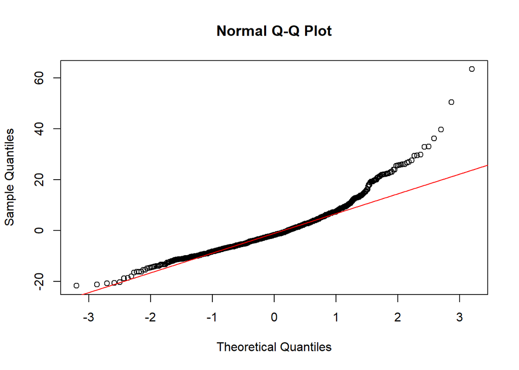

```r
# q-q plot za normalnost reziduala
qqnorm(residuals(fit.multi22))
qqline(residuals(fit.multi22), col = "red")
```

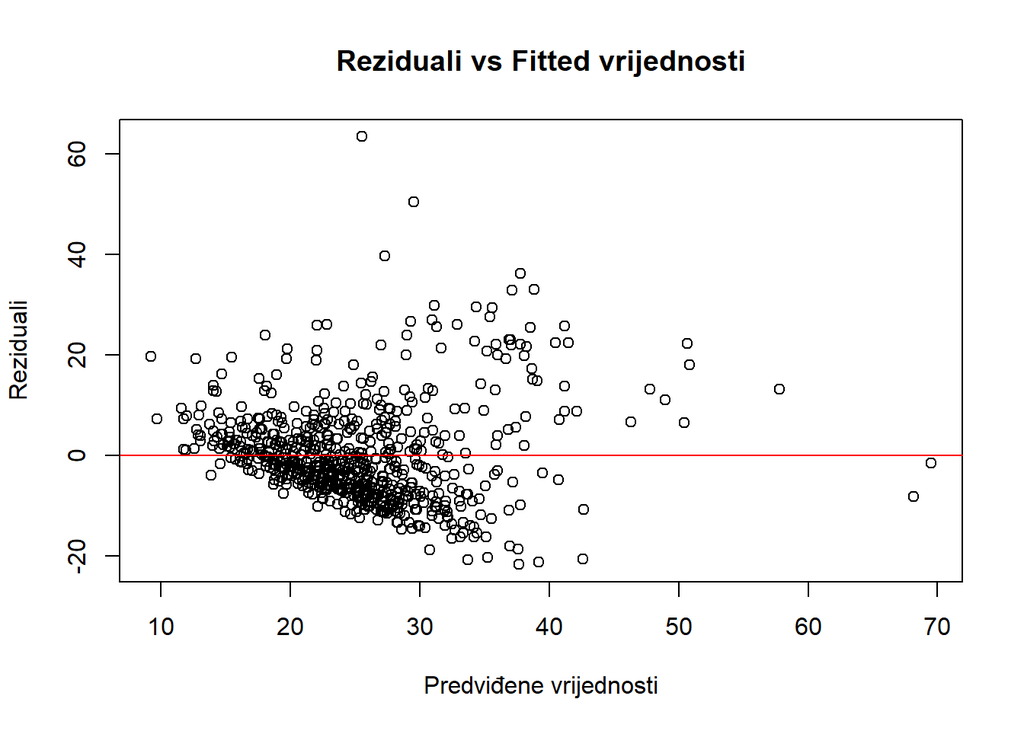

```r
# testiranje homogenosti varijance
# Scatter plot reziduala
plot(fitted(fit.multi22), residuals(fit.multi22), main = "Reziduali vs Fitted vrijednosti",
     xlab = "Predviđene vrijednosti", ylab = "Reziduali")
abline(h = 0, col = "red")
```